# What made you happy today?

Shengwei Huang

# About the dataset

Many things can make one’s heart smile with joy. HappyDB(https://rit-public.github.io/HappyDB/) is “a corpus of 100,000 crowd-sourced happy moments”. The goal of this project is to look deeper into the causes that make us happy. Natural language processing and text mining are natural tools to derive interesting findings in this collection of happy moments.

# What really “connects” us to happy moments?

I accidentally came across a passage which tells people how to make most of you life happy moments. It mentions top 10 ways to achieve these happy moments:

1. Tell friends, “The greatest thing happened to me!”
2. Mentally Instagram it
3. Do a touchdown dance
4. Close your eyes at the concert
5. Say, “I’m normally at work right now”
6. Be Zen and don’t think anything at all
7. Shout, “Hooray!”
8. Remember: This will end
9. Say, “I am so lucky to have this in my life”
10. Do not say, “I should be working right now”

The author thinks that happy moments may usually happen when you share your day with your friends, family, or even just someone on your instagram. Sometimes happy momemnts may also happy when you just keeping relaxing yourself or encouraging yourself. Thus I am going to look deep inside that: 1. Which kind of words may appear in different happy category? 2. For different people(male,female,single,married,ect.), to them which are the “happy” words they frequent used?

# Exploratory data analysis

Let’s first have an overview of our text data.

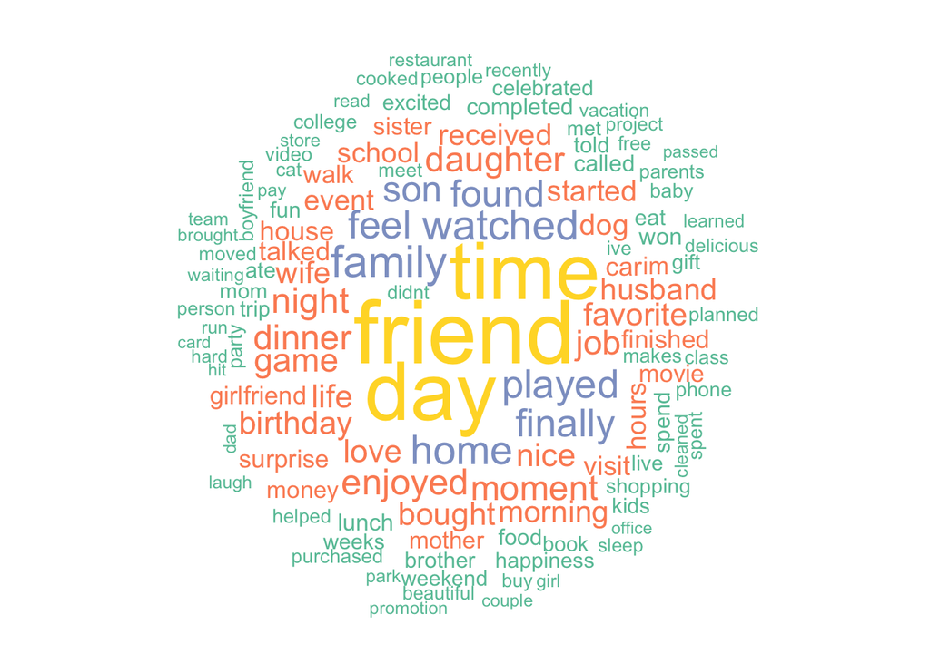

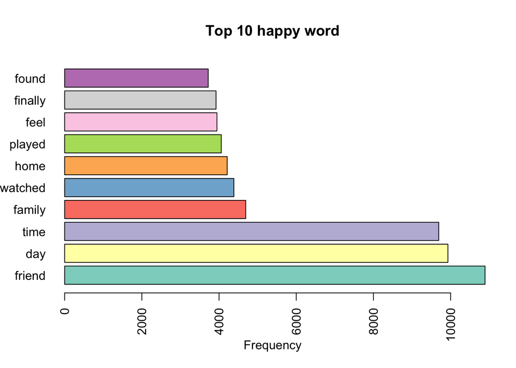

We can see that the words rank into Top 10 words that appear most frequently in happy moments are:

TOP1. FRIEND

TOP2. DAY

TOP3. TIME

TOP4. FAMILY

TOP5. WATCHED

TOP6. HOME

TOP7. PLAYED

TOP8. FEEL

TOP9. FINALLY

TOP10. FOUND

Now, let’s divide all happy moments into 7 different category which are: affection, achievement, enjoy the moment, bonding, excerices, nature and leisure. We are going to look at the top 10 frequnt used words under these 7 categories:

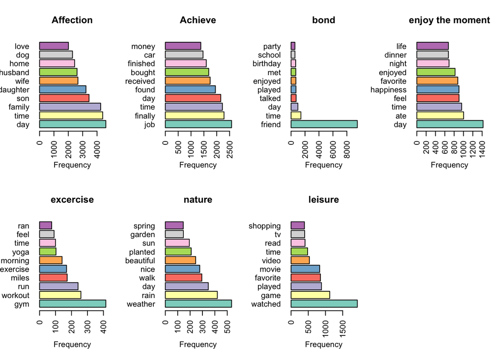

Now,moving on to the next part of question: Different groups of people with different happy moements, are there any obvious trend for different groups?

Let’s compare Male vs Female first:

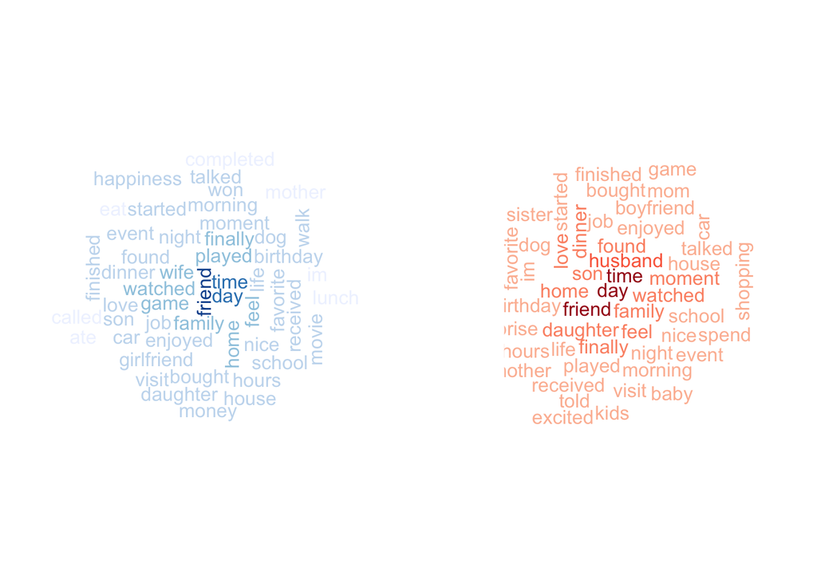

The blue wordcloud is for male and the red one is for female. Just briefly look at them, we can fidn the top 3 “happy” word are the same for both male and female: 1.friend 2.day 3.time which is also corresponding to the top 3 for all individuals.

However, male groups differs from the female groups when we continue to comapre. For male group, we can see other “happy” word contains: “wife”,“played”,“game”,“daughter”,“car”. For female group we can find words:“baby”,“dinner”,“husband”,“found”,“mom”,ect. Thus male groups tend to make happy moment while they playing games, staying with their wife or talk about cars while female groups tend to make happy moments when they are talking about baby, stay with their husband or cooking dinners for her family.

Next, let’s compare people that have already become parents and those who are not.

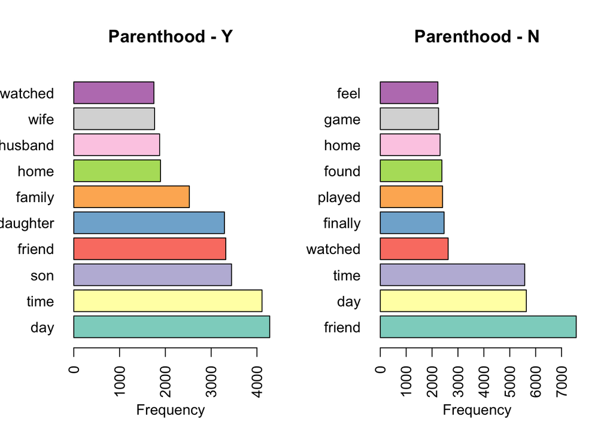

We can see the obvious difference beteween people with/without parenthood. For those who already formed their own family, they tend to make more happy moments with their family member such as: son,daughter, husband, wife. However,for the other group, people more frequently have happy moment when they spending time with friends, palying some sports or games or watching movies. That’s significant difference between parenthood and without parenthood.

Then, we are going to look at the people with different marital status.

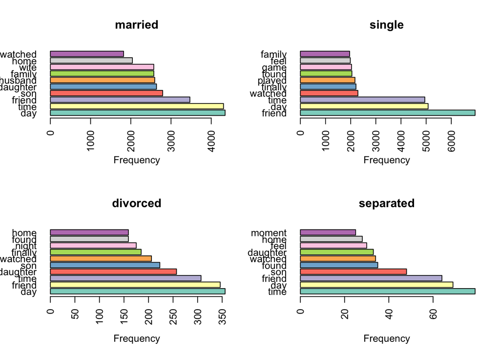